```python
# Import necessary libraries
import pandas as pd
import matplotlib.pyplot as plt
import seaborn as sns
```

```python
# Load data
data=pd.read_csv('Data-Week2.csv')
# Read data
data.head(2)
```

|  | County | Total Active Borrowers | Very Low Income | Low Income | Married | American Indian/Alaskan Native | Asian | Black/African American | Hawaiin Pacific Islander | White | Hispanic | Average Number of Children | Average Household Size |
| --- | --- | --- | --- | --- | --- | --- | --- | --- | --- | --- | --- | --- | --- |
| 0 | 1003 | 368 | 157 | 210 | 82 | 3 | 0 | 146 | 1 | 202 | 8 | 1.1 | 2.2 |
| 1 | 1005 | 124 | 34 | 91 | 23 | 0 | 0 | 108 | 0 | 12 | 0 | 1.0 | 2.0 |

# 1. Visualizing County and Borrowers Data: Histogram and Box Chart Analysis.

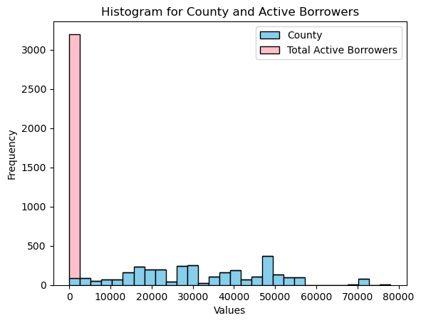

```python
# Create Histogram for 'County' and 'Total Active Borrowers'
x=data["County"]
y=data["Total Active Borrowers"]
plt.hist([x,y], bins=30, stacked=True, color=['skyblue', 'pink'], edgecolor='black')
plt.title('Histogram for County and Active Borrowers')
plt.xlabel('Values')
plt.ylabel('Frequency')
plt.legend(['County', 'Total Active Borrowers'])
plt.show()
```

# Interpretation

## The histogram shows a significant difference in the distribution between counties and total active borrowers. County values are spread relatively evenly across a wide range, with multiple smaller peaks indicating that certain counties appear more frequently than others. On the other hand, the distribution of total active borrowers is heavily concentrated towards the lower end, with a large spike near zero. This suggests that most counties have very few active borrowers, and only a small number of counties have higher numbers. Overall, there is an imbalance in borrower distribution, as a large proportion of the counties have minimal borrower activity.

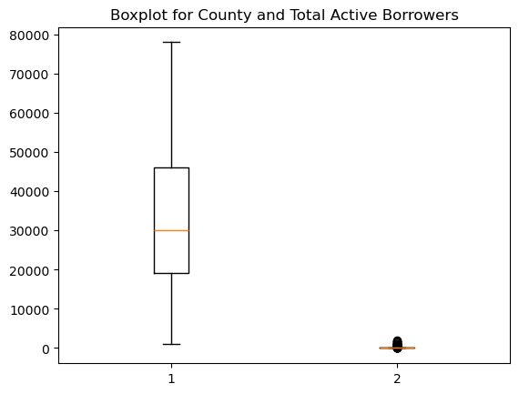

```python
# Create Boxplot for 'County' and 'Total Active Borrowers'
x = data["County"]
y =data["Total Active Borrowers"]
plt.boxplot([x, y])
plt.title('Boxplot for County and Total Active Borrowers')
plt.show()
```

## The boxplot further highlights the imbalance between counties and active borrowers. County values are distributed more widely, with a relatively balanced spread around the median, while the total active borrowers are tightly clustered around very low values. This tight clustering, along with the presence of a few outliers, indicates that the majority of counties have small borrower populations, with a few exceptions where borrower numbers are much higher. The outliers, represented as individual points, suggest that some counties stand out with exceptionally high borrower numbers, which are far from the majority of the data.

# 2. Exploring Feature Correlations: Scatter Plot Analysis of data.

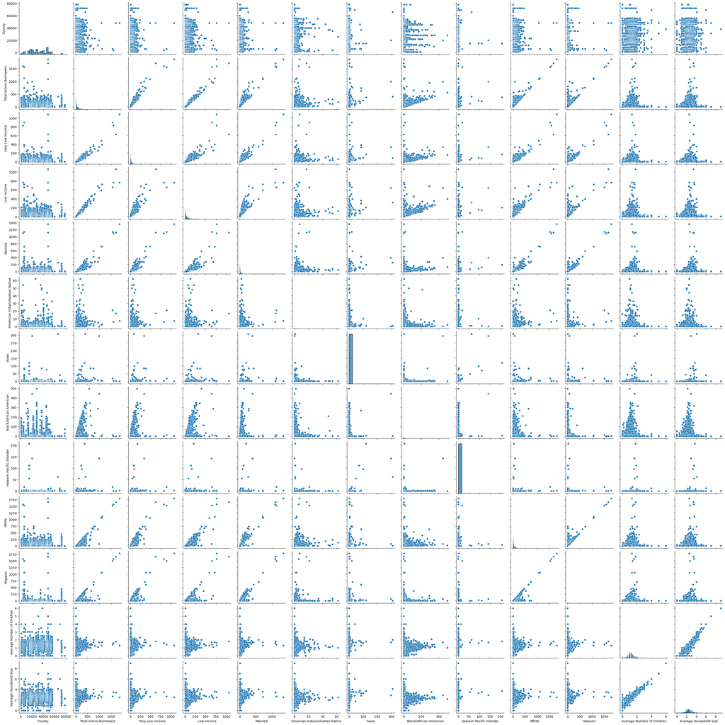

```python
# Create a scatter Plot for All Features
sns.pairplot(data)
plt.show()
```

# Interpretation

## The scatter plot analysis reveals that there are high correlations between the number of active borrowers and individuals in the very low-income category. This trend suggests that regions with higher levels of poverty may experience greater demand for loans or financial assistance. Additionally, the strong positive correlation between very low-income and low-income groups indicates that areas with more individuals in the very low-income category are likely to have more low-income residents. This connection reflects how socioeconomic factors often cluster together.

## The analysis also shows a positive correlation between the White population and total active borrowers, indicating demographic patterns in loan utilization. Additionally, the strong correlation between the average number of children and household size reflects expected trends. The link between married individuals and active borrowers suggests that married couples may be more likely to take out loans for major life expenses. Together, these correlations demonstrate how borrowing patterns are influenced by socioeconomic and demographic factors, offering insights into how financial services are utilized across different population groups.